# Lab 1 code

### 7.2. Task 5B

In this task we change the batch size, one value at a time. The batch size changes how many noisy gradient updates fit in one epoch, so it affects both generalization and wall-clock time. We pick three sizes that bracket a wide range.

The first batch size is 16

```
=== 5B | Batch size: 16 ===
Overall Accuracy: 0.965
```

|  | precision | recall | f1-score | support |
| --- | --- | --- | --- | --- |
| Benign | 0.997 | 0.958 | 0.977 | 2533.0 |
| Brute Force | 0.827 | 0.986 | 0.900 | 214.0 |
| DoS Hulk | 0.930 | 0.986 | 0.957 | 580.0 |
| PortScan | 0.627 | 0.977 | 0.764 | 43.0 |
| macro avg | 0.845 | 0.977 | 0.899 | 3370.0 |
| weighted avg | 0.970 | 0.965 | 0.966 | 3370.0 |

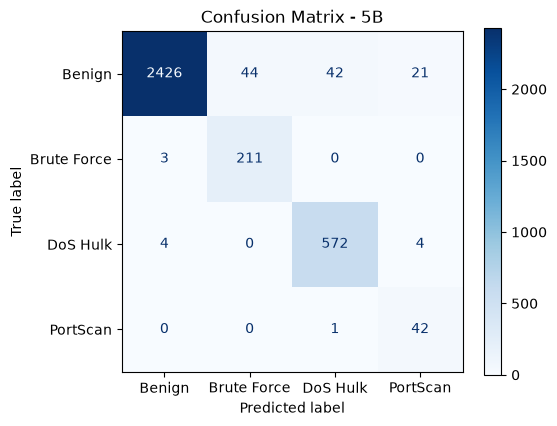

```
Best epoch: 50 | epochs run: 60 | time: 37.7 s
```

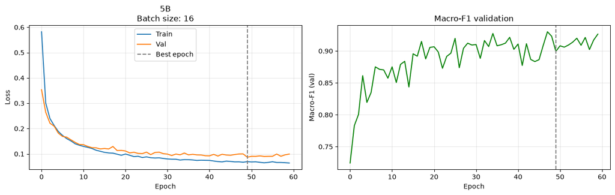

```python
r12   = run_experiment("5B", "Batch size: 16",   data=D2, batch_size=16,   **T5)
```

The second batch size is 1024

```
=== 5B | Batch size: 1024 ===
Overall Accuracy: 0.954
```

|  | precision | recall | f1-score | support |
| --- | --- | --- | --- | --- |
| Benign | 0.995 | 0.946 | 0.970 | 2533.0 |
| Brute Force | 0.799 | 0.986 | 0.883 | 214.0 |
| DoS Hulk | 0.919 | 0.976 | 0.946 | 580.0 |
| PortScan | 0.506 | 0.977 | 0.667 | 43.0 |
| macro avg | 0.805 | 0.971 | 0.866 | 3370.0 |
| weighted avg | 0.963 | 0.954 | 0.956 | 3370.0 |

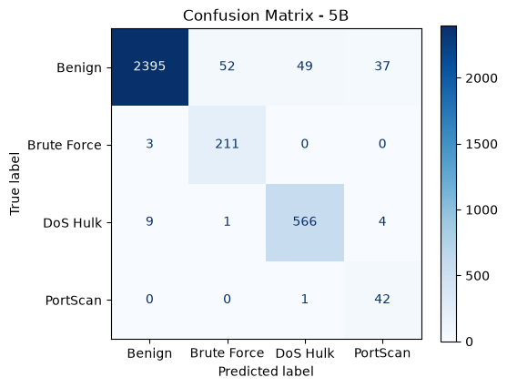

```
Best epoch: 293 | epochs run: 300 | time: 15.8 s
```

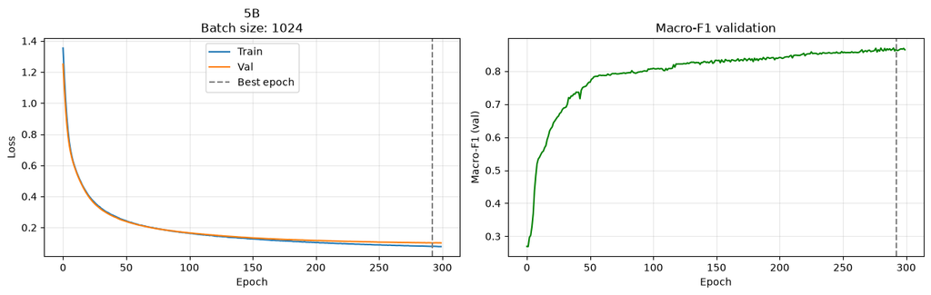

```python
r13 = run_experiment("5B", "Batch size: 1024", data=D2, batch_size=1024, **T5)
```

The third batch size is 128

```
=== 5B | Batch size: 128 ===
Overall Accuracy: 0.957
```

|  | precision | recall | f1-score | support |
| --- | --- | --- | --- | --- |
| Benign | 0.996 | 0.949 | 0.972 | 2533.0 |
| Brute Force | 0.834 | 0.986 | 0.904 | 214.0 |
| DoS Hulk | 0.924 | 0.981 | 0.952 | 580.0 |
| PortScan | 0.483 | 0.977 | 0.646 | 43.0 |
| macro avg | 0.809 | 0.973 | 0.868 | 3370.0 |
| weighted avg | 0.967 | 0.957 | 0.960 | 3370.0 |

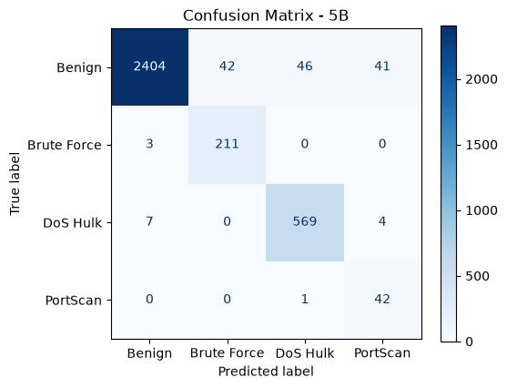

```
Best epoch: 99 | epochs run: 109 | time: 12.2 s
```

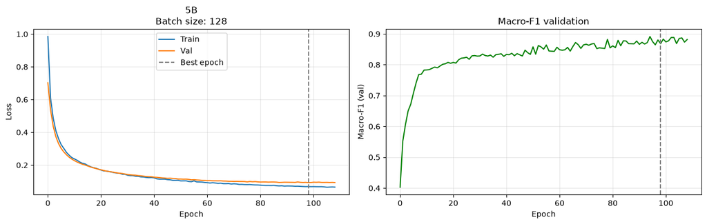

```python
r14 = run_experiment("5B", "Batch size: 128", data=D2, batch_size=128, **T5)
```

*Q: Report validation results and training time, and explain both.*

[output not shown]

### 7.3. Task 5C

In this task, we use different combinations of optimizer and learning rates.

Firstly, we train with standard SGD optimizer with $0.01$ learning rate

```
=== 5C1 | SGD (lr=0.01) ===
Overall Accuracy: 0.906
```

|  | precision | recall | f1-score | support |
| --- | --- | --- | --- | --- |
| Benign | 0.986 | 0.891 | 0.936 | 2533.0 |
| Brute Force | 0.583 | 0.986 | 0.733 | 214.0 |
| DoS Hulk | 0.876 | 0.941 | 0.908 | 580.0 |
| PortScan | 0.412 | 0.930 | 0.571 | 43.0 |
| macro avg | 0.715 | 0.937 | 0.787 | 3370.0 |
| weighted avg | 0.935 | 0.906 | 0.914 | 3370.0 |

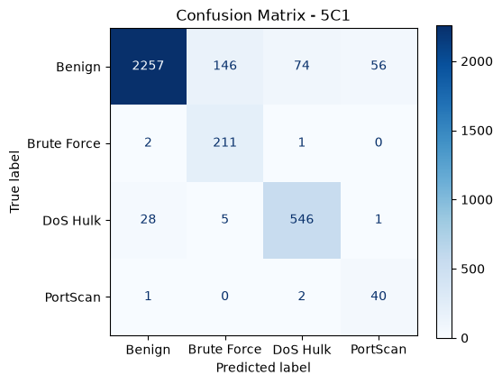

```
Best epoch: 120 | epochs run: 130 | time: 22.8 s
```

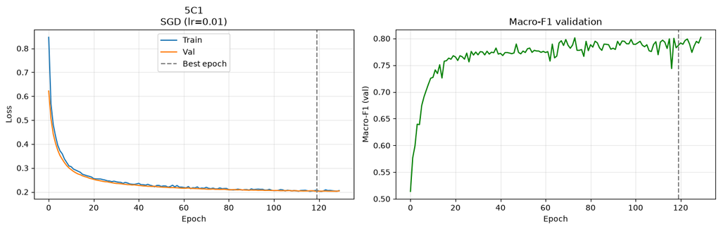

```python
r15 = run_experiment("5C1", "SGD (lr=0.01)", data=D2, optimizer="sgd", lr=0.01, momentum=0.0, **T5)
```

Secondly, we train with a higher learning rate of $0.1$ keeping the same optimizer

```
=== 5C2 | SGD (lr=0.1) ===
Overall Accuracy: 0.920
```

|  | precision | recall | f1-score | support |
| --- | --- | --- | --- | --- |
| Benign | 0.983 | 0.912 | 0.946 | 2533.0 |
| Brute Force | 0.621 | 0.986 | 0.762 | 214.0 |
| DoS Hulk | 0.893 | 0.931 | 0.911 | 580.0 |
| PortScan | 0.506 | 0.907 | 0.650 | 43.0 |
| macro avg | 0.751 | 0.934 | 0.817 | 3370.0 |
| weighted avg | 0.939 | 0.920 | 0.925 | 3370.0 |

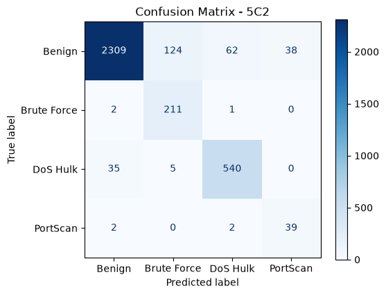

```
Best epoch: 17 | epochs run: 27 | time: 5.4 s
```

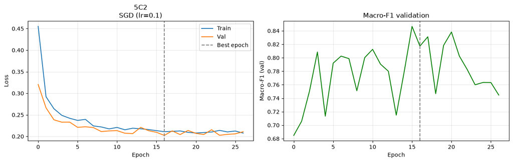

```python
r16 = run_experiment("5C2", "SGD (lr=0.1)", data=D2, optimizer="sgd", lr=0.1, momentum=0.0, **T5)
```

Next, we take the initial SGD setup and add a momentum factor of $0.9$

```
=== 5C3 | SGD + Momentum 0.9 (lr=0.01) ===
Overall Accuracy: 0.905
```

|  | precision | recall | f1-score | support |
| --- | --- | --- | --- | --- |
| Benign | 0.988 | 0.889 | 0.936 | 2533.0 |
| Brute Force | 0.589 | 0.986 | 0.738 | 214.0 |
| DoS Hulk | 0.874 | 0.947 | 0.909 | 580.0 |
| PortScan | 0.381 | 0.930 | 0.541 | 43.0 |
| macro avg | 0.708 | 0.938 | 0.781 | 3370.0 |
| weighted avg | 0.935 | 0.905 | 0.913 | 3370.0 |

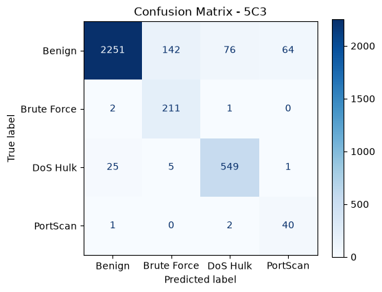

```
Best epoch: 60 | epochs run: 70 | time: 12.4 s
```

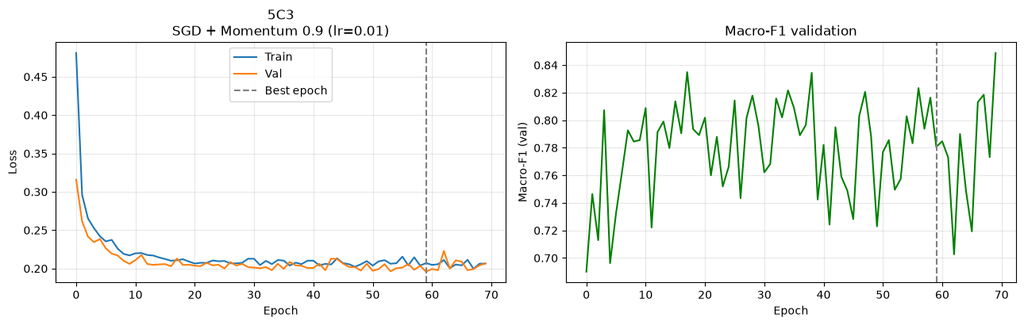

```python
r17 = run_experiment("5C3", "SGD + Momentum 0.9 (lr=0.01)", data=D2, optimizer="sgd", lr=0.01, momentum=0.9, **T5)
```

Finally, we use AdamW optimizer with learning rate $5 \times 10^{-3}$

```
=== 5C4 | AdamW (lr=5e-3) ===
Overall Accuracy: 0.964
```

|  | precision | recall | f1-score | support |
| --- | --- | --- | --- | --- |
| Benign | 0.998 | 0.957 | 0.977 | 2533.0 |
| Brute Force | 0.815 | 0.991 | 0.895 | 214.0 |
| DoS Hulk | 0.933 | 0.988 | 0.960 | 580.0 |
| PortScan | 0.618 | 0.977 | 0.757 | 43.0 |
| macro avg | 0.841 | 0.978 | 0.897 | 3370.0 |
| weighted avg | 0.970 | 0.964 | 0.966 | 3370.0 |

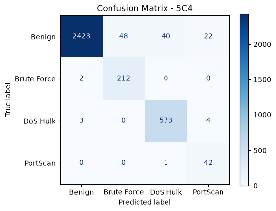

```
Best epoch: 21 | epochs run: 31 | time: 6.0 s
```

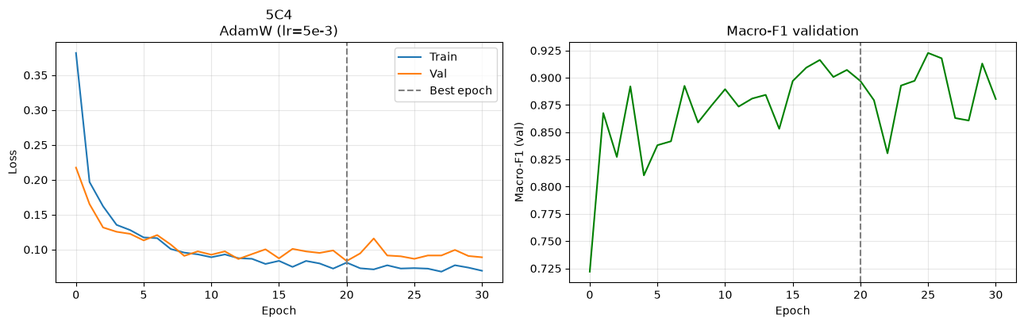

```python
r18 = run_experiment("5C4", "AdamW (lr=5e-3)", data=D2, lr=5e-3, **T5)
```

*Q: What did you find: does the optimizer or the learning rate dominate on this data?*

The optimizer family sets the level; inside a family the learning-rate effects are below the 0.05 noise threshold. Inside SGD, 10x the learning rate (0.01 to 0.1) moves macro-F1 from 0.787 to 0.817 (+0.030) and the run from 130 to 27 epochs: the gain is noise, only the number of epochs is a solid effect. Momentum 0.9 at lr 0.01 gives 0.781 (-0.006), also noise, and raising the AdamW learning rate from 5e-4 (`r8`) to 5e-3 (`r18`) moves macro-F1 by +0.013, noise as well. Between families, AdamW at the same weight decay reaches 0.897, +0.080 over the best SGD run: the only difference of this section above the threshold. Caveats: the comparison between AdamW and SGD changes the optimizer and the learning rate together, so it cannot attribute the gap to either; and weight decay is not the same operation in the two optimizers (decoupled in AdamW, L2 added to the gradient in SGD). A possible reason for the low SGD scores is that SGD cannot afford a weight decay of 0.01 at these learning rates, but this is a hypothesis that we did not test: no SGD run uses weight decay 0.

### 7.4. Task 5D

We take the best model of the ones we trained in this task on validation and put it against our initial baseline, on the test set. All the Task 5 runs start from the weighted `r8`, so the comparison with the unweighted `r7` contains the effect of the loss as well as the effect of the architecture; we report `r8` in the table so that the two can be read separately.

```
============ Unweighted baseline (r7) ============
--- TEST (loss 0.0523) ---
```

|  | precision | recall | f1-score | support |
| --- | --- | --- | --- | --- |
| Benign | 0.984 | 0.990 | 0.987 | 2534.00 |
| Brute Force | 0.944 | 0.953 | 0.949 | 214.00 |
| DoS Hulk | 0.975 | 0.953 | 0.964 | 580.00 |
| PortScan | 0.974 | 0.884 | 0.927 | 43.00 |
| accuracy | 0.980 | 0.980 | 0.980 | 0.98 |
| macro avg | 0.970 | 0.945 | 0.957 | 3371.00 |
| weighted avg | 0.980 | 0.980 | 0.980 | 3371.00 |

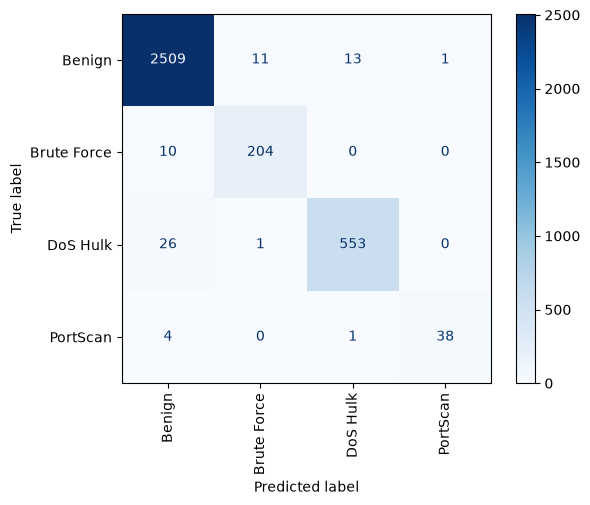

```
============ Weighted baseline (r8) ============
--- TEST (loss 0.1091) ---
```

|  | precision | recall | f1-score | support |
| --- | --- | --- | --- | --- |
| Benign | 0.995 | 0.943 | 0.968 | 2534.000 |
| Brute Force | 0.804 | 0.995 | 0.889 | 214.000 |
| DoS Hulk | 0.904 | 0.976 | 0.939 | 580.000 |
| PortScan | 0.532 | 0.977 | 0.689 | 43.000 |
| accuracy | 0.952 | 0.952 | 0.952 | 0.952 |
| macro avg | 0.809 | 0.973 | 0.871 | 3371.000 |
| weighted avg | 0.961 | 0.952 | 0.955 | 3371.000 |

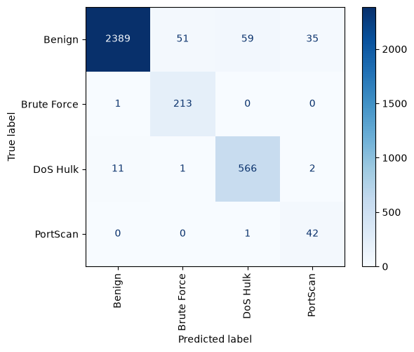

```
============ 5A (128,64,32) (r11) ============
--- TEST (loss 0.0844) ---
```

|  | precision | recall | f1-score | support |
| --- | --- | --- | --- | --- |
| Benign | 0.998 | 0.957 | 0.977 | 2534.000 |
| Brute Force | 0.813 | 0.995 | 0.895 | 214.000 |
| DoS Hulk | 0.919 | 0.995 | 0.955 | 580.000 |
| PortScan | 0.808 | 0.977 | 0.884 | 43.000 |
| accuracy | 0.966 | 0.966 | 0.966 | 0.966 |
| macro avg | 0.884 | 0.981 | 0.928 | 3371.000 |
| weighted avg | 0.970 | 0.966 | 0.967 | 3371.000 |

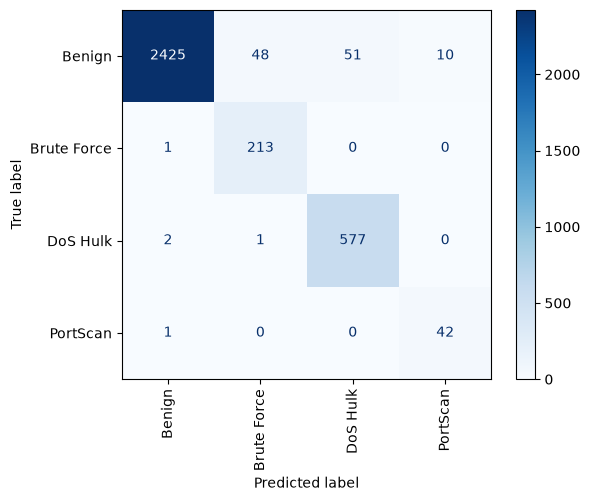

```
Comparison table
```

|  | Unweighted baseline (r7) | Weighted baseline (r8) | 5A (128,64,32) (r11) |
| --- | --- | --- | --- |
| loss | 0.0523 | 0.1091 | 0.0844 |
| macro_F1 | 0.9568 | 0.8712 | 0.9279 |
| recall_Benign | 0.9901 | 0.9428 | 0.9570 |
| recall_Brute Force | 0.9533 | 0.9953 | 0.9953 |
| recall_DoS Hulk | 0.9534 | 0.9759 | 0.9948 |
| recall_PortScan | 0.8837 | 0.9767 | 0.9767 |

```python
# Evaluate several models on the same split.
def compare_models(models, data=D2, split="test"):
    results = {}

    for name, exp in models.items():
        print("=" * 12, name, "=" * 12)
        results[name] = eval_split(exp["model"], data, split)

    results_df = pd.DataFrame({
        name: [res["loss"], res["macro_f1"], *res["recall"]]
        for name, res in results.items()
    }, index=["loss", "macro_F1"] + [f"recall_{n}" for n in data["class_names"]])
    results_df.index.name = None

    print("Comparison table")
    display(results_df.round(4))


# Task 5D: the best Task 5 model against both Task 4 baselines.
compare_models({"Unweighted baseline (r7)": r7,
                "Weighted baseline (r8)": r8,
                "5A (128,64,32) (r11)": r11})
```

*Q: Did the added complexity beat the simple baseline? Was it worth the runs it cost?*

No, and the comparison has to be read in two steps. On test the unweighted baseline `r7` reaches macro-F1 0.957 / accuracy 0.980, the best Task 5 model `r11` 0.928 / 0.966 (0.029 below, within noise) and the weighted baseline `r8` 0.871 / 0.952 (0.086 below, above the threshold). The gap between `r11` and `r7` cannot be assigned: `r11` keeps the weighted loss of `r8`, and the weights alone cost more than the architecture changes. Inside Task 5 the model that catches the most PortScan (recall 0.977 against 0.884 of `r7`) also produces the most false alarms (precision 0.808 against 0.974). Ten runs of Task 5 produced no model better than the 1x64 network of Task 4 beyond noise, and the runs were not worth it beyond what we learned about depth, batch size and optimizers.

## 8. Task 6

This task deals with overfitting problems and how to minimize them.

We start from a new baseline (as specified by the lab document) and train it

R19 uses the class-weighted cross-entropy of `r8` (balanced weights from the training split) and AdamW with weight decay 0; the weights of the last epoch (200) are evaluated because there is no early stopping. With respect to `r8` it changes the architecture, the batch size, the weight decay and the stopping rule at once, as the lab prescribes.

```
=== 6A | Large 5-layer network (no regularization, no early stopping) ===
Overall Accuracy: 0.979
```

|  | precision | recall | f1-score | support |
| --- | --- | --- | --- | --- |
| Benign | 0.998 | 0.976 | 0.987 | 2533.0 |
| Brute Force | 0.865 | 0.986 | 0.921 | 214.0 |
| DoS Hulk | 0.954 | 0.993 | 0.973 | 580.0 |
| PortScan | 0.891 | 0.953 | 0.921 | 43.0 |
| macro avg | 0.927 | 0.977 | 0.951 | 3370.0 |
| weighted avg | 0.981 | 0.979 | 0.979 | 3370.0 |

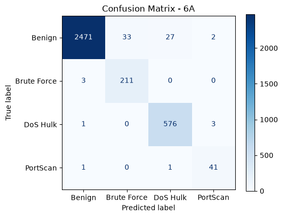

```
Best epoch: 44 | epochs run: 200 | time: 33.0 s
```

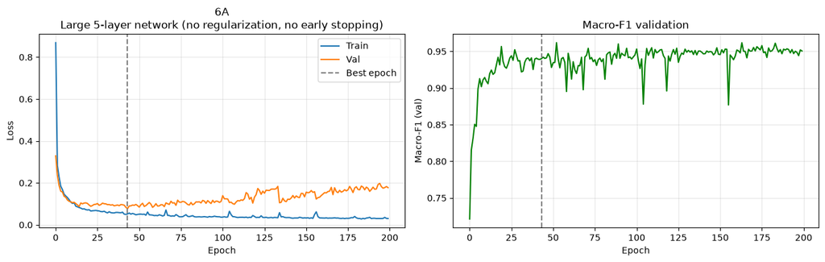

```python
# Task 6 setup: large network, no regularization and no early stopping.
T6 = dict(class_weight="balanced", weight_decay=0.0,
          restore_best=False, patience=10**9,
          epochs=200, batch_size=128, hidden_sizes=(256, 128, 64, 32, 16))
r19 = run_experiment("6A", "Large 5-layer network (no regularization, no early stopping)", data=D2, **T6)
```

To confirm the presence of overfitting, we use the `eval_split` function to create a comparison table

```
--- TRAIN (loss 0.0576) ---
```

|  | precision | recall | f1-score | support |
| --- | --- | --- | --- | --- |
| Benign | 0.999 | 0.972 | 0.986 | 11821.000 |
| Brute Force | 0.866 | 0.999 | 0.928 | 999.000 |
| DoS Hulk | 0.944 | 0.995 | 0.969 | 2708.000 |
| PortScan | 0.913 | 1.000 | 0.954 | 199.000 |
| accuracy | 0.978 | 0.978 | 0.978 | 0.978 |
| macro avg | 0.931 | 0.992 | 0.959 | 15727.000 |
| weighted avg | 0.980 | 0.978 | 0.979 | 15727.000 |

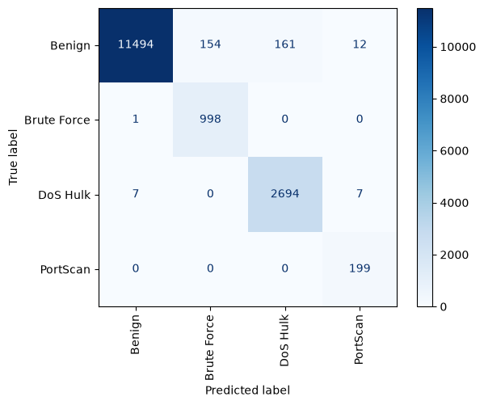

```
--- VAL (loss 0.0717) ---
```

|  | precision | recall | f1-score | support |
| --- | --- | --- | --- | --- |
| Benign | 0.998 | 0.976 | 0.987 | 2533.000 |
| Brute Force | 0.865 | 0.986 | 0.921 | 214.000 |
| DoS Hulk | 0.954 | 0.993 | 0.973 | 580.000 |
| PortScan | 0.891 | 0.953 | 0.921 | 43.000 |
| accuracy | 0.979 | 0.979 | 0.979 | 0.979 |
| macro avg | 0.927 | 0.977 | 0.951 | 3370.000 |
| weighted avg | 0.981 | 0.979 | 0.979 | 3370.000 |

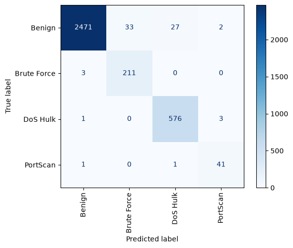

|  | train | val | gap |
| --- | --- | --- | --- |
| loss | 0.0576 | 0.0717 | 0.0141 |
| macro_F1 | 0.9591 | 0.9506 | -0.0085 |
| recall_Benign | 0.9723 | 0.9755 | 0.0032 |
| recall_Brute Force | 0.9990 | 0.9860 | -0.0130 |
| recall_DoS Hulk | 0.9948 | 0.9931 | -0.0017 |
| recall_PortScan | 1.0000 | 0.9535 | -0.0465 |

```
Weighted validation loss: minimum 0.0774 at epoch 44, final 0.1774
Weighted training loss: at epoch 44 0.0518, final 0.0302
The evaluated weights are those of epoch 200 (restore_best=False).
```

```python
train_res = eval_split(r19["model"], D2, "train")
val_res = eval_split(r19["model"], D2, "val")

# Train vs validation: a big gap means overfitting.
overfitting_df = pd.DataFrame({
    "train": [train_res["loss"], train_res["macro_f1"], *train_res["recall"]],
    "val": [val_res["loss"], val_res["macro_f1"], *val_res["recall"]]
}, index=["loss", "macro_F1"] + [f"recall_{n}" for n in D2["class_names"]]).round(4)

overfitting_df["gap"] = (overfitting_df["val"] - overfitting_df["train"]).round(4)
overfitting_df.index.name = None

display(overfitting_df)

# The curves of the figure use the weighted criterion of `fit`; the table above is unweighted.
h19 = r19["hist"]
vmin = int(np.argmin(h19["val_loss"]))
print(f"Weighted validation loss: minimum {h19['val_loss'][vmin]:.4f} at epoch {vmin + 1}, "
      f"final {h19['val_loss'][-1]:.4f}")
print(f"Weighted training loss: at epoch {vmin + 1} {h19['train_loss'][vmin]:.4f}, "
      f"final {h19['train_loss'][-1]:.4f}")
print("The evaluated weights are those of epoch 200 (restore_best=False).")
```

*Q: Is it overfitting? Show exactly where you see it in the curves.*

Mildly, and the curves show exactly where. Up to epoch ~45 the train and validation losses fall together; the minimum of the weighted validation loss is at epoch 44 (0.077). After that the training loss keeps falling (to ~0.03) while the validation loss rises steadily (to ~0.18 at epoch 200): the hypothesis that it would flatten was wrong, it rises. The table, computed with the unweighted loss, shows a smaller gap with the same shape (train 0.058, validation 0.072). The two losses are not comparable: `fit` evaluates with the weighted criterion used for training (validation 0.177 at epoch 200), `eval_split` with an unweighted one, and 0.072 is an unweighted final value, not the minimum of the curve. Accuracy is almost identical (train 0.978, validation 0.979) but PortScan recall is 1.000 on train against 0.953 on validation, so the memorisation is concentrated in the rarest class.

Now that we confirmed overfitting, we can start mitigating it. The first countermeasure we implement is early stopping. We define a new configuration `T6A`

```
=== 6B | Early stopping ===
Overall Accuracy: 0.965
```

|  | precision | recall | f1-score | support |
| --- | --- | --- | --- | --- |
| Benign | 0.997 | 0.959 | 0.977 | 2533.0 |
| Brute Force | 0.824 | 0.986 | 0.898 | 214.0 |
| DoS Hulk | 0.918 | 0.986 | 0.951 | 580.0 |
| PortScan | 0.750 | 0.977 | 0.848 | 43.0 |
| macro avg | 0.872 | 0.977 | 0.919 | 3370.0 |
| weighted avg | 0.969 | 0.965 | 0.966 | 3370.0 |

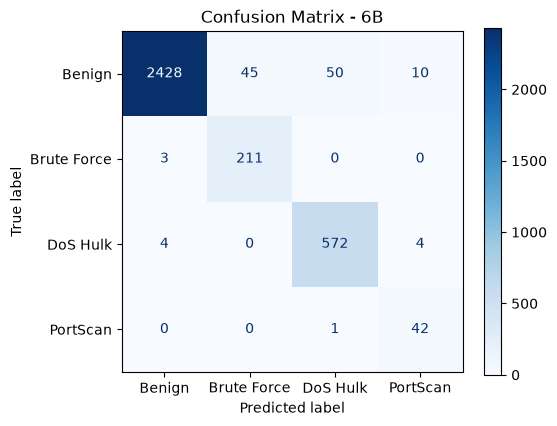

```
Best epoch: 15 | epochs run: 25 | time: 4.0 s
```

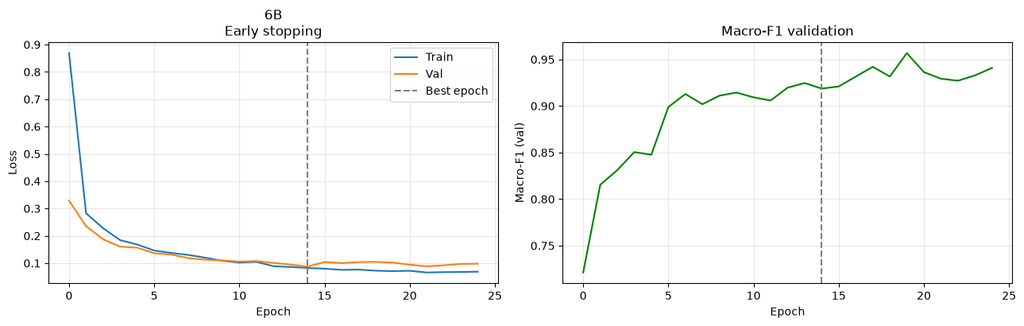

```python
# Same setup as T6, but with early stopping.
T6A = {**T6, "patience": 10, "restore_best": True}

r20 = run_experiment("6B", "Early stopping", data=D2, **T6A)
```

Then, we add a weight decay of $0.01$ on top of early stopping.

```
=== 6C | Weight decay (0.01) with early stopping ===
Overall Accuracy: 0.967
```

|  | precision | recall | f1-score | support |
| --- | --- | --- | --- | --- |
| Benign | 0.997 | 0.961 | 0.979 | 2533.0 |
| Brute Force | 0.831 | 0.986 | 0.902 | 214.0 |
| DoS Hulk | 0.925 | 0.984 | 0.954 | 580.0 |
| PortScan | 0.750 | 0.977 | 0.848 | 43.0 |
| macro avg | 0.876 | 0.977 | 0.921 | 3370.0 |
| weighted avg | 0.971 | 0.967 | 0.968 | 3370.0 |

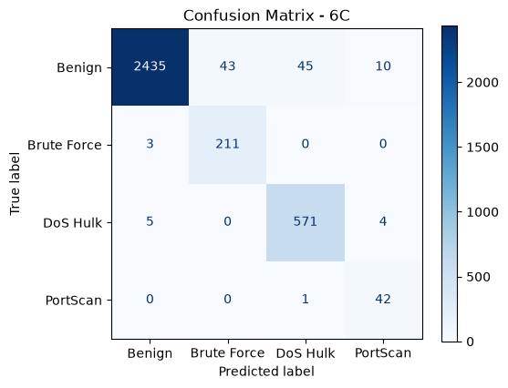

```
Best epoch: 15 | epochs run: 25 | time: 4.4 s
```

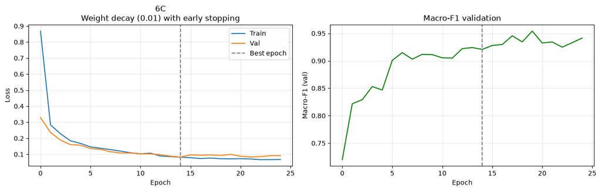

```python
r21 = run_experiment("6C", "Weight decay (0.01) with early stopping", data=D2, **{**T6A, "weight_decay": 0.01})
```

This configuration will become our baseline for our next experiment. We introduce dropout layers, with probability $24\%$

```
=== 6D | Dropout (0.24) with early stopping and weight decay ===
Overall Accuracy: 0.969
```

|  | precision | recall | f1-score | support |
| --- | --- | --- | --- | --- |
| Benign | 0.998 | 0.963 | 0.980 | 2533.0 |
| Brute Force | 0.815 | 0.986 | 0.892 | 214.0 |
| DoS Hulk | 0.939 | 0.990 | 0.964 | 580.0 |
| PortScan | 0.764 | 0.977 | 0.857 | 43.0 |
| macro avg | 0.879 | 0.979 | 0.923 | 3370.0 |
| weighted avg | 0.973 | 0.969 | 0.970 | 3370.0 |

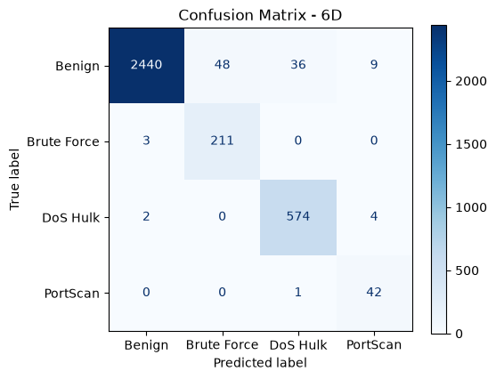

```
Best epoch: 42 | epochs run: 52 | time: 9.1 s
```

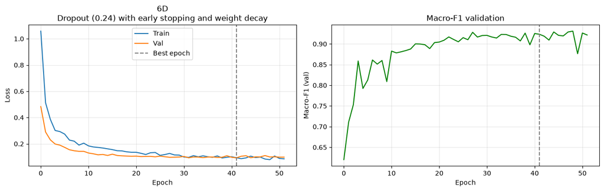

```python
# Dropout on top of weight decay.
T6B = {**T6A, "weight_decay": 0.01}

r22 = run_experiment("6D", "Dropout (0.24) with early stopping and weight decay", data=D2, **{**T6B, "dropout": 0.24})
```

In this section we add batch normalization to the previous configuration

```
=== 6E | Added Batch Normalization ===
Overall Accuracy: 0.964
```

|  | precision | recall | f1-score | support |
| --- | --- | --- | --- | --- |
| Benign | 0.999 | 0.955 | 0.977 | 2533.0 |
| Brute Force | 0.804 | 0.995 | 0.889 | 214.0 |
| DoS Hulk | 0.923 | 0.991 | 0.956 | 580.0 |
| PortScan | 0.689 | 0.977 | 0.808 | 43.0 |
| macro avg | 0.854 | 0.980 | 0.907 | 3370.0 |
| weighted avg | 0.970 | 0.964 | 0.965 | 3370.0 |

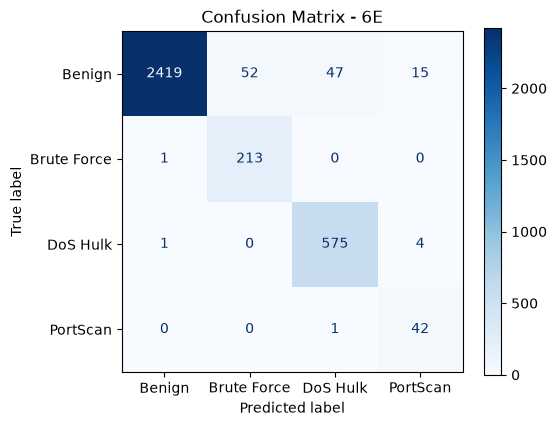

```
Best epoch: 32 | epochs run: 42 | time: 10.8 s
```

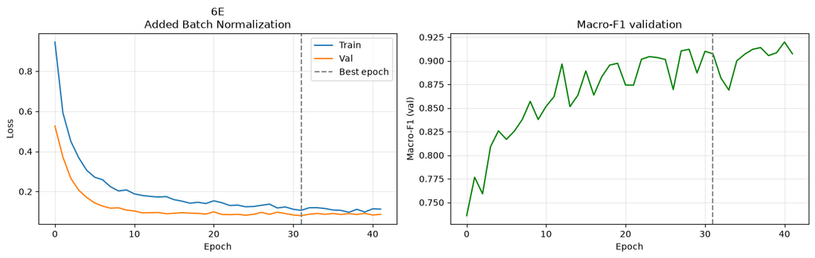

```python
r23 = run_experiment("6E", "Added Batch Normalization", data=D2, **{**T6B, "dropout": 0.24, "batchnorm": True})
```

Finally, we test the other half of the first countermeasure: instead of stopping earlier we make the network much smaller, with a single 64-unit hidden layer. The run keeps the Task 6 protocol of `T6` (no weight decay, no dropout, no batch normalization, 200 epochs, no early stopping), so that only the capacity changes.

```
=== 6F | Single 64-unit hidden layer ===
Overall Accuracy: 0.970
```

|  | precision | recall | f1-score | support |
| --- | --- | --- | --- | --- |
| Benign | 0.998 | 0.964 | 0.981 | 2533.0 |
| Brute Force | 0.841 | 0.991 | 0.910 | 214.0 |
| DoS Hulk | 0.933 | 0.991 | 0.962 | 580.0 |
| PortScan | 0.737 | 0.977 | 0.840 | 43.0 |
| macro avg | 0.877 | 0.981 | 0.923 | 3370.0 |
| weighted avg | 0.974 | 0.970 | 0.971 | 3370.0 |

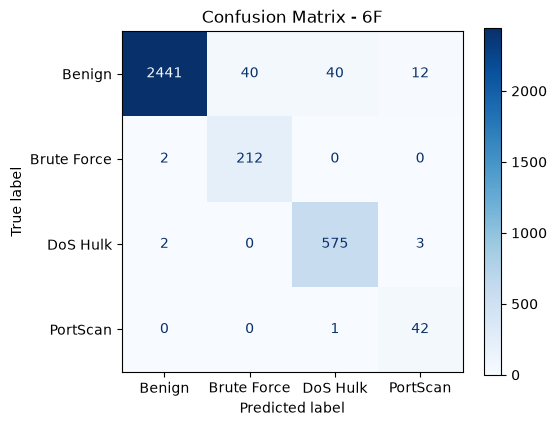

```
Best epoch: 117 | epochs run: 200 | time: 23.7 s
```

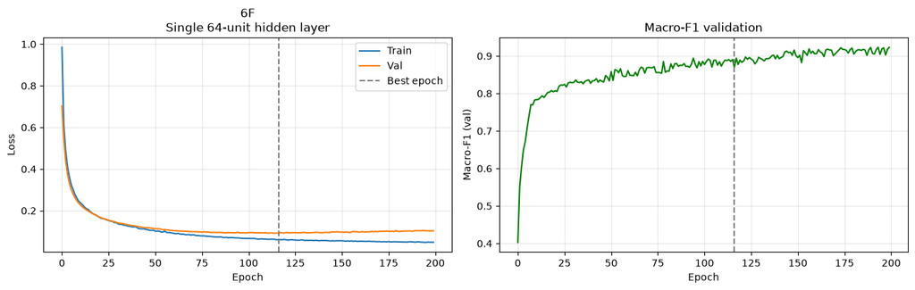

```python
r24 = run_experiment("6F", "Single 64-unit hidden layer", data=D2, **{**T6, "hidden_sizes": (64,)})
```

*Q: Which change helped the most for the least effort?*

In conclusion, we compare the Task 4 baseline `r8` with the best regularized 5-layer network of Task 6 (`r22`) and with the smaller one-layer network `r24`. We also evaluate `r19`, the best Task 6 model on validation (0.951), which was not on the test set before: the rule is that the best validation model of the task goes to test, and `r22` and `r24` are reported for comparison. Evaluating an already trained model on test is not a new run.

```
============ Weighted baseline (r8) ============
--- TEST (loss 0.1091) ---
```

|  | precision | recall | f1-score | support |
| --- | --- | --- | --- | --- |
| Benign | 0.995 | 0.943 | 0.968 | 2534.000 |
| Brute Force | 0.804 | 0.995 | 0.889 | 214.000 |
| DoS Hulk | 0.904 | 0.976 | 0.939 | 580.000 |
| PortScan | 0.532 | 0.977 | 0.689 | 43.000 |
| accuracy | 0.952 | 0.952 | 0.952 | 0.952 |
| macro avg | 0.809 | 0.973 | 0.871 | 3371.000 |
| weighted avg | 0.961 | 0.952 | 0.955 | 3371.000 |

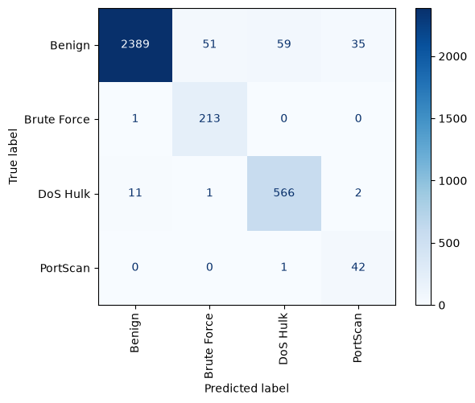

```
============ 5-layer, no regularization (r19) ============
--- TEST (loss 0.0555) ---
```

|  | precision | recall | f1-score | support |
| --- | --- | --- | --- | --- |
| Benign | 0.997 | 0.977 | 0.987 | 2534.000 |
| Brute Force | 0.892 | 1.000 | 0.943 | 214.000 |
| DoS Hulk | 0.953 | 0.988 | 0.970 | 580.000 |
| PortScan | 0.915 | 1.000 | 0.956 | 43.000 |
| accuracy | 0.981 | 0.981 | 0.981 | 0.981 |
| macro avg | 0.939 | 0.991 | 0.964 | 3371.000 |
| weighted avg | 0.982 | 0.981 | 0.981 | 3371.000 |

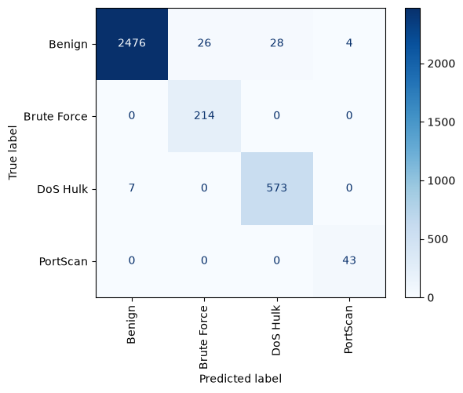

```
============ Dropout 5-layer (r22) ============
--- TEST (loss 0.0970) ---
```

|  | precision | recall | f1-score | support |
| --- | --- | --- | --- | --- |
| Benign | 0.998 | 0.954 | 0.976 | 2534.000 |
| Brute Force | 0.792 | 0.995 | 0.882 | 214.000 |
| DoS Hulk | 0.917 | 0.993 | 0.954 | 580.000 |
| PortScan | 0.827 | 1.000 | 0.905 | 43.000 |
| accuracy | 0.964 | 0.964 | 0.964 | 0.964 |
| macro avg | 0.884 | 0.986 | 0.929 | 3371.000 |
| weighted avg | 0.969 | 0.964 | 0.965 | 3371.000 |

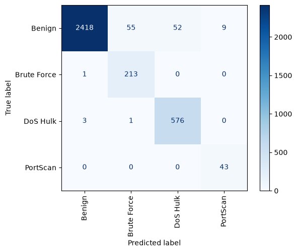

```
============ 1x64, no regularization (r24) ============
--- TEST (loss 0.0842) ---
```

|  | precision | recall | f1-score | support |
| --- | --- | --- | --- | --- |
| Benign | 0.998 | 0.958 | 0.977 | 2534.000 |
| Brute Force | 0.810 | 0.995 | 0.893 | 214.000 |
| DoS Hulk | 0.927 | 0.988 | 0.957 | 580.000 |
| PortScan | 0.768 | 1.000 | 0.869 | 43.000 |
| accuracy | 0.966 | 0.966 | 0.966 | 0.966 |
| macro avg | 0.876 | 0.985 | 0.924 | 3371.000 |
| weighted avg | 0.971 | 0.966 | 0.967 | 3371.000 |

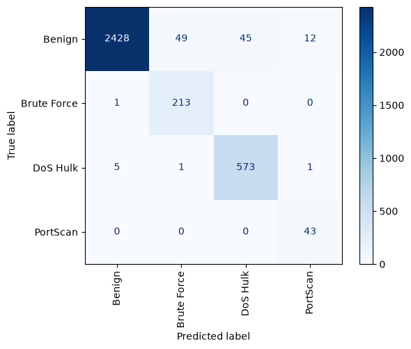

```
Comparison table
```

|  | Weighted baseline (r8) | 5-layer, no regularization (r19) | Dropout 5-layer (r22) | 1x64, no regularization (r24) |
| --- | --- | --- | --- | --- |
| loss | 0.1091 | 0.0555 | 0.0970 | 0.0842 |
| macro_F1 | 0.8712 | 0.9639 | 0.9292 | 0.9240 |
| recall_Benign | 0.9428 | 0.9771 | 0.9542 | 0.9582 |
| recall_Brute Force | 0.9953 | 1.0000 | 0.9953 | 0.9953 |
| recall_DoS Hulk | 0.9759 | 0.9879 | 0.9931 | 0.9879 |
| recall_PortScan | 0.9767 | 1.0000 | 1.0000 | 1.0000 |

```python
# Final test comparison: the best Task 6 model on validation (r19), the best regularized
# 5-layer network (r22), the one-layer network (r24) and the weighted Task 4 baseline (r8).
compare_models({"Weighted baseline (r8)": r8,
                "5-layer, no regularization (r19)": r19,
                "Dropout 5-layer (r22)": r22,
                "1x64, no regularization (r24)": r24})
```

*Q: In the end, did the big network, even with regularization, do better on the test set than the simple port-free baseline?*

No better beyond noise. On test `r7` reaches 0.957 / 0.980; the unregularized `r19`, the best Task 6 model on validation, 0.964 / 0.981 (+0.007, noise); the regularized `r22` 0.929 / 0.964 and the one-layer `r24` 0.924 / 0.966, both nominally below `r7` but within noise. Against the weighted `r8` (0.871 / 0.952), all three are above the threshold: `r19` +0.093, `r22` +0.058, `r24` +0.053. The weighted loss had cost 0.086 and the Task 6 networks recover it, but not through regularization: `r24` has no regularizer and recovers as much as `r22`, and `r19`, which has none either, recovers all of it. What `r19` and `r24` change with respect to `r8` is the protocol (batch 128, weight decay 0, no early stopping, 200 epochs); the runs do not say which of the four matters, and for `r24` it cannot be the capacity, which is the same as `r8`'s. Per class, `r22` finds PortScan more often (recall 1.000 vs 0.884) with more false alarms (precision 0.827 vs 0.974) and is worse on Brute Force (F1 0.882 vs 0.949); `r19` has PortScan precision / recall 0.915 / 1.000 and Brute Force F1 0.943. The simple 1x64 unweighted network is as good as any model of the lab.

*Q: Looking across the whole logbook, which decisions gave the most performance per unit of effort?*

The data decisions, not the models. Applying `log1p` + `StandardScaler` moved validation macro-F1 from 0.921 (no scaling) to 0.983 with a few lines of code, and no architecture change came close: the five-layer network of Task 6 is 0.008 below the unweighted single layer of Task 4 on validation (0.951 against 0.959), less than the noise threshold. Stratifying removes a several-point swing in the share of a class that has 43 flows in test. Removing the port moved macro-F1 by -0.024, below the threshold, and removed a shortcut that was worth all of Brute Force recall (1.000 to 0.000 when only the port was changed in Task 3). Class weights bought rare-class recall (PortScan 0.907 to 0.977) at the price of macro-F1 (0.959 to 0.884). Depth, width, batch size and optimizer moved macro-F1 by less than the threshold, except SGD, which lost it.